# Consommation d’électricité et de gaz

Hamady Cissé

## Introduction

J’ai choisi de travailler sur un jeu de données qui permet de visualiser l’évolution de 2011 à 2020 des consommations d’électricité et de gaz par secteur d’activité (résidentiel, tertiaire, industriel, agricole ou non affecté) et par commune.

## Visualisation

```r
library(ggplot2)
library(tidyverse)
library(RColorBrewer)
library(viridis)
library(geojsonio)
library(MASS)
library(scales)
library(readxl)
library(dplyr)
library(GGally)
library(maps)
library(raster)
library(sf)
library(cowplot)
```

```r
#setwd("C:/Users/hamad/Desktop")
conso<-read.csv("conso-elec-gaz-annuelle-par-secteur-dactivite-agregee-commune.csv",header =TRUE,sep = ";")
```

```r
names(conso)
```

```
##  [1] "Opérateur"
##  [2] "Année"
##  [3] "Filière"
##  [4] "Consommation.Agriculture..MWh."
##  [5] "Nombre.de.points.Agriculture"
##  [6] "Nombre.de.mailles.secretisées..agriculture."
##  [7] "Indique.qualité.Agriculture"
##  [8] "Consommation.Industrie..MWh."
##  [9] "Nombre.de.points.Industrie"
## [10] "Nombre.de.mailles.secretisées..industrie."
## [11] "Indice.qualité.Industrie"
## [12] "Consommation.Tertiaire...MWh."
## [13] "Nombre.de.points.Tertiaire"
## [14] "Nombre.de.mailles.secretisées..tertiaire."
## [15] "Indice.qualité.Tertiaire"
```

[output cut: 21 more lines]

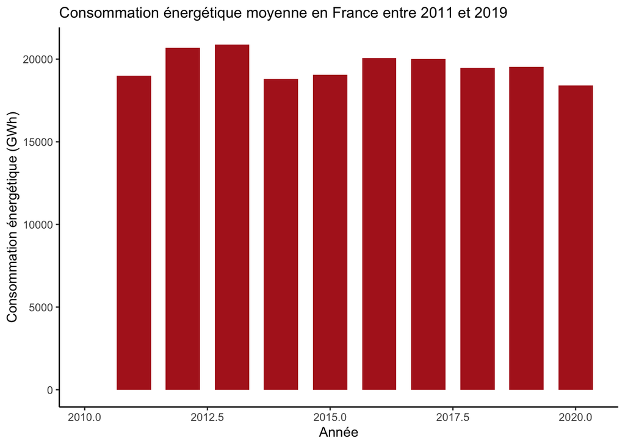

```r
conso %>% group_by(Année) %>% summarise(moy_conso = mean(Consommation.totale..MWh.)) -> conso_moyenne_par_an
ggplot(conso_moyenne_par_an) +
geom_bar(aes(x=Année, y=moy_conso),fill="firebrick",
stat = "identity",width=0.7)+
expand_limits(x=c(2010,2020), y=c(0, 100))+
theme_classic()+
theme(legend.title = element_blank(),plot.title = element_text(size=12))+
xlab("Année")+
ylab("Consommation énergétique (GWh)")+
ggtitle("Consommation énergétique moyenne en France entre 2011 et 2019")
```

On remarque que sur le graphique que la consommation d’électricité et de gaz n’a pas beaucoup varié ces 10 dernières années avec des observations plus faibles en 2011 et 2014 et 2020. Regardons maintenant les principaux secteurs qui amènent à cette consommation.

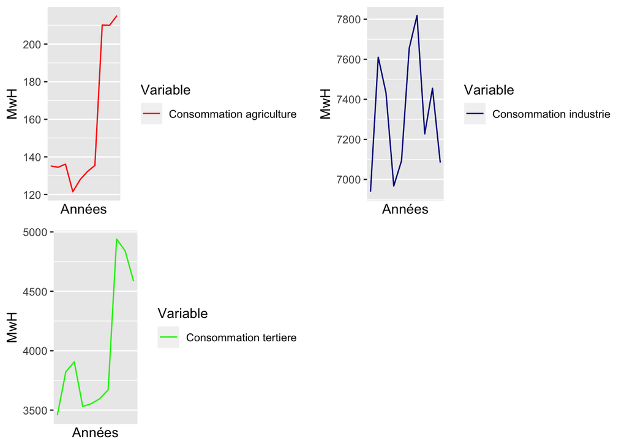

```r
conso %>% group_by(Année) %>% summarise(moy_conso_Agri = mean(Consommation.Agriculture..MWh.)) -> conso_moyenne_par_an_Agri
conso %>% group_by(Année) %>% summarise(moy_conso_Indus = mean(Consommation.Industrie..MWh.)) -> conso_moyenne_par_an_Indus
conso %>% group_by(Année) %>% summarise(moy_conso_Tert = mean(Consommation.Tertiaire...MWh.)) -> conso_moyenne_par_an_Tert

ggplot(conso_moyenne_par_an_Agri) +
  geom_line(aes(x = Année, y = moy_conso_Agri,color='Consommation agriculture')) +
  scale_color_manual(values = c('Consommation agriculture' = 'red')) +
  scale_x_continuous(breaks=seq(1970,1982,2)) +
  labs(color = 'Variable') +
  labs(x = "Années", y = "MwH") -> A
ggplot(conso_moyenne_par_an_Indus) +
  geom_line(aes(x = Année, y = moy_conso_Indus,color='Consommation industrie')) +
  scale_color_manual(values = c('Consommation industrie' = 'darkblue')) +
  scale_x_continuous(breaks=seq(1970,1982,2)) +
  labs(color = 'Variable')  +
  labs(x = "Années", y = "MwH") -> B
ggplot(conso_moyenne_par_an_Tert) +
  geom_line(aes(x = Année, y = moy_conso_Tert,color='Consommation tertiere')) +
  scale_color_manual(values = c('Consommation tertiere' = 'green2')) +
  scale_x_continuous(breaks=seq(1970,1982,2)) +
  labs(color = 'Variable') +
  labs(x = "Années", y = "MwH") -> C

plot_grid(A,B,C,labels=c("","",""),ncol = 2, nrow = 2)
```

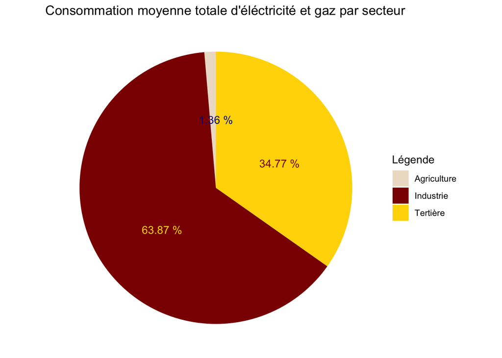

```r
x <- sum(conso_moyenne_par_an_Agri$moy_conso_Agri)/10
y <- sum(conso_moyenne_par_an_Indus$moy_conso_Indus)/10
z <- sum(conso_moyenne_par_an_Tert$moy_conso_Tert)/10

count.data <- data.frame(
  Légende <- c("Agriculture", "Industrie", "Tertière"),
  a <- c(x,y,z),
  prop <- c('1.36 %','63.87 %','34.77 %'))

mycols <- c("antiquewhite2", "darkred", "gold")

ggplot(count.data, aes(x = "", y = a, fill = Légende)) +
  geom_bar(width = 1, stat = "identity") +
  coord_polar("y")+
  geom_text(aes(y = c(1,7400,2200) ,label=prop),color = c('blue4','gold','darkred'))+
  scale_fill_manual(values = mycols)+
  theme_void()+
  ggtitle("Consommation moyenne totale d'éléctricité et gaz par secteur")
```

Le diagramme circulaire fait ci-dessus vient renforcer le fait que les consommations industrielles et tertières occupent une place importante en France contrairement aux consommations agricoles.

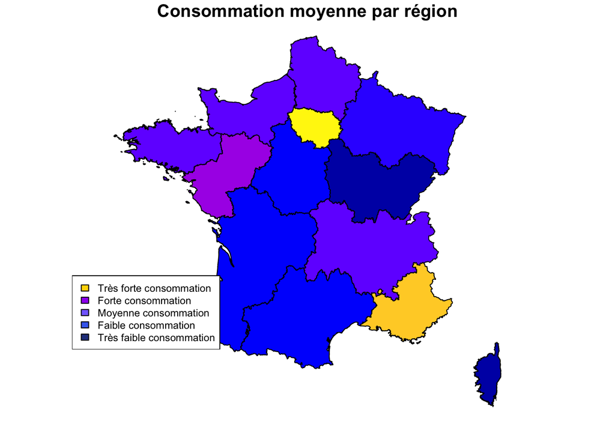

```r
FranceFormes <- getData(name="GADM", country="FRA", level=1)

names(conso)[33] <- 'NAME_1'

france <- st_as_sf(FranceFormes)
france <- st_transform(france)

conso %>% group_by(NAME_1) %>%
  summarise(`Consommation moyenne par région` = mean(Consommation.totale..MWh.)) -> conso_moyenne

france <- left_join(france,conso_moyenne)

france %>% relocate(`Consommation moyenne par région`,.before = GID_0) -> france

plot(france, max.plot = 1)
legend("bottomleft",cex=0.7,legend = c("Très forte consommation",
                               "Forte consommation",
                               "Moyenne consommation",
                               "Faible consommation",
                               "Très faible consommation"),
       fill = c('gold','purple','slateblue1','royalblue2','royalblue4'))
```

Le graphique ci dessus qui est une carte de la France nous permet de voir le niveau de consommation d’électricité et de gaz dans les régions de France entre 2011 et 2020 en fonction des couleurs.  
On remarque que les consommations sont majoritairement faibles ou moyennnes excepté au Pays de la Loire où il y a une forte consommation.  
De plus, nous pouvons rajouter que les régions qui consomment davantage en France sont l’Ile de France et la Provence Alpes-cote d’Azur.  
Le faite que ce soit les deux regions les plus peuplés de france nous amènent à imaginer que ceux sont les plus gros consommateurs d’energie.  
Une variable population pour chaque region aurait pu être très pertinente car on remarque que la présence de la population influe énormement sur la consommation de gaz et d’elctricité.